# Анализ клиентской базы ОТП-банка

Пак Дарья, Романов Борис, Вотякова Мария БЛГ153

# Введение

Этот набор был подготовлен для конкурса по решению прикладной задачи предсказания отклика клиентов на маркетинговую кампанию в рамках всероссийской конференции «Математические методы распознавания образов» ММРО-15 (2011). Описание и результаты конкурса размещены на ресурсе www.machinelearning.ru в разделе “Конкурсы”.

Данные предоставлены ОТП Банком (www.otpbank.ru), который входит в число 50 крупнейших банков России, занимает 2-е место на рынке потребительского кредитования, 3-е место на рынке беззалогового кредитования, и 4-е место на рынке кредитных карт.

# Постановка задачи

Один из способов повышения эффективности взаимодействия банка с клиентами заключается в том, чтобы отправлять предложение о новой услуге не всем клиентам банка, а только некоторой части, выбираемой по принципу наибольшей склонности к отклику на данное предложение.

В этом задании вам предстоит выполнить разведочный анализ данных о клиентах банка с целью выявления факторов, влияющих на отклик.

# Описание данных

Исходная выборка («выборка А») содержит записи о 15 223 клиентов, классифицированных на два класса: 1 — отклик был (1812 клиентов), 0 — отклика не было (13411 клиентов).

Данные находятся в файле: `otp_bank.xlsx`, описание переменных доступно на листе `fields`.

# Подготовка данных к анализу

## Загрузка и изучение структуры данных

```r
library(tidyverse)
library(forcats) # удобная работа с факторами
library(readxl) # считывание данных из Excel
library(scales) # Форматирование осей на графиках ggplot
library(mapproj)
library(dplyr)
library(gridExtra)
library(grid)
library(ggthemes)
library(RColorBrewer)
library(ggfortify)
library(rworldmap)
```

Загрузим данные и описание переменных.

```r
otp <- read_excel('otp_bank.xlsx')
fields <- read_excel('otp_bank.xlsx', 2)
```

После загрузки необходимо изучить структуру данных, диапазоны изменения всех величин, наличие пропусков, аномальных значений.

```r
glimpse(otp) # Тип данных столбцов (можно использовать вместо str())
```

```
## Observations: 15,223
## Variables: 52
## $ agreement_rk               <dbl> 59910150, 59910230, 59910525, 59910...
## $ target                     <dbl> 0, 0, 0, 0, 0, 0, 0, 0, 0, 0, 0, 1,...
## $ age                        <dbl> 49, 32, 52, 39, 30, 29, 35, 41, 53,...
## $ socstatus_work_fl          <chr> "работает", "работает", "работает",...
## $ socstatus_pens_fl          <chr> "не пенсионер", "не пенсионер", "не...
## $ gender                     <dbl> 1, 1, 1, 1, 0, 0, 0, 1, 0, 1, 1, 0,...
## $ child_total                <dbl> 2, 3, 4, 1, 0, 0, 1, 0, 2, 0, 2, 0,...
## $ dependants                 <dbl> 1, 3, 0, 1, 0, 0, 1, 0, 0, 0, 0, 0,...
## $ education                  <chr> "Среднее специальное", "Среднее", "...
## $ marital_status             <chr> "Состою в браке", "Состою в браке",...
## $ gen_industry               <chr> "Торговля", "Торговля", "Информацио...
## $ gen_title                  <chr> "Рабочий", "Рабочий", "Специалист",...
## $ org_tp_state               <chr> "Частная компания", "Индивидуальный...
```

[output cut: 39 more lines]

```r
filter(fields, name == 'dependants') # Как посмотреть назначение переменной
```

```
## # A tibble: 1 x 2
##         name                   description
##        <chr>                         <chr>
## 1 dependants количество иждивенцев клиента
```

```r
summary(otp) # Описательная статистика по каждой переменной
```

```
##   agreement_rk          target           age        socstatus_work_fl
##  Min.   :59910150   Min.   :0.000   Min.   :21.00   Length:15223
##  1st Qu.:61920915   1st Qu.:0.000   1st Qu.:30.00   Class :character
##  Median :64370996   Median :0.000   Median :39.00   Mode  :character
##  Mean   :65401831   Mean   :0.119   Mean   :40.41
##  3rd Qu.:67088018   3rd Qu.:0.000   3rd Qu.:50.00
##  Max.   :75292242   Max.   :1.000   Max.   :67.00
##
##  socstatus_pens_fl      gender        child_total       dependants
##  Length:15223       Min.   :0.0000   Min.   : 0.000   Min.   :0.0000
##  Class :character   1st Qu.:0.0000   1st Qu.: 0.000   1st Qu.:0.0000
##  Mode  :character   Median :1.0000   Median : 1.000   Median :0.0000
##                     Mean   :0.6545   Mean   : 1.099   Mean   :0.6452
##                     3rd Qu.:1.0000   3rd Qu.: 2.000   3rd Qu.:1.0000
##                     Max.   :1.0000   Max.   :10.000   Max.   :7.0000
##
##   education         marital_status     gen_industry
##  Length:15223       Length:15223       Length:15223
##  Class :character   Class :character   Class :character
##  Mode  :character   Mode  :character   Mode  :character
##
##
##
##
##   gen_title         org_tp_state       org_tp_fcapital
##  Length:15223       Length:15223       Length:15223
##  Class :character   Class :character   Class :character
##  Mode  :character   Mode  :character   Mode  :character
##
##
##
##
##    job_dir          family_income      personal_income
##  Length:15223       Length:15223       Min.   :    24
##  Class :character   Class :character   1st Qu.:  8000
##  Mode  :character   Mode  :character   Median : 12000
##                                        Mean   : 13854
##                                        3rd Qu.: 17000
##                                        Max.   :250000
##
```

[output cut: 65 more lines]

```
##  Min.   :0.0000   Min.   :    0.0   Min.   :    0
##  1st Qu.:0.0000   1st Qu.:    0.0   1st Qu.:    0
##  Median :0.0000   Median :    0.0   Median :    0
##  Mean   :0.1302   Mean   :  239.5   Mean   :  243
##  3rd Qu.:0.0000   3rd Qu.:    0.0   3rd Qu.:    0
##  Max.   :8.0000   Max.   :28012.2   Max.   :28012
##
##  previous_card_num_utilized
##  Min.   :0.000
##  1st Qu.:1.000
##  Median :1.000
##  Mean   :1.003
##  3rd Qu.:1.000
##  Max.   :2.000
##  NA's   :14934
```

```r
unique(otp$education) # Какие значения встречаются в столбце
```

```
## [1] "Среднее специальное"            "Среднее"
## [3] "Неполное среднее"               "Высшее"
## [5] "Неоконченное высшее"            "Два и более высших образования"
## [7] "Ученая степень"
```

```r
table(otp$education) # Таблица частот
```

```
##
##                         Высшее Два и более высших образования
##                           3133                             20
##            Неоконченное высшее               Неполное среднее
##                            532                            340
##                        Среднее            Среднее специальное
##                           4679                           6518
##                 Ученая степень
##                              1
```

```r
NAs <- colSums(is.na(otp)) # Количество пропущенных значений
NAs[NAs > 0] # В каких переменных есть пропуски?
```

```
##               gen_industry                  gen_title
##                       1367                       1367
##               org_tp_state            org_tp_fcapital
##                       1367                       1365
##                    job_dir                tp_province
##                       1367                        295
##                  region_nm                  work_time
##                          1                       1368
## previous_card_num_utilized
##                      14934
```

## Удаление аномальных значений

Для замены аномальных значений на пропуски (NA) удобно использовать функцию `ifelse()` (замена по условию) или `na_if()` (замена конкретного значения).

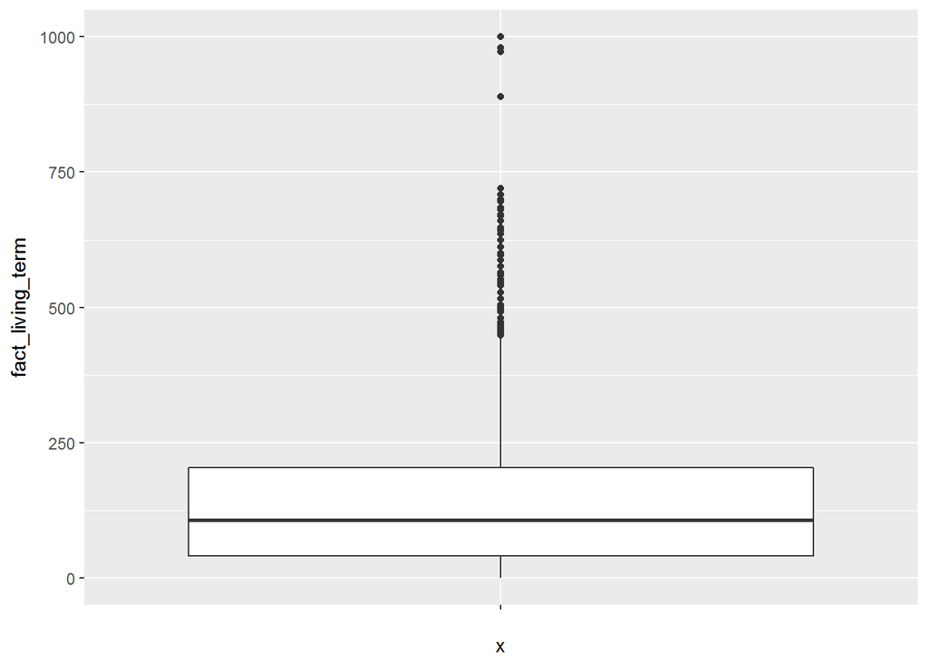

```r
otp <- otp %>%
  mutate(fact_living_term =
           ifelse(fact_living_term > 1000 | fact_living_term < 0,
                  NA, fact_living_term))

ggplot(otp, aes(x = "", y = fact_living_term)) +
  geom_boxplot()
```

Аналогичным образом удалите аномальные значения из поля `work_time`.

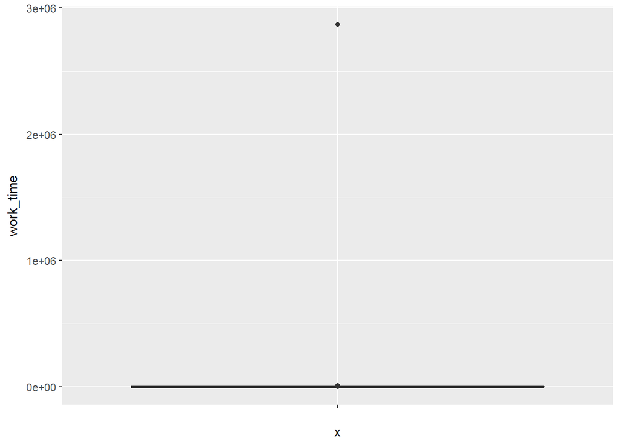

```r
ggplot(otp, aes(x = "", y = work_time)) +
  geom_boxplot()
```

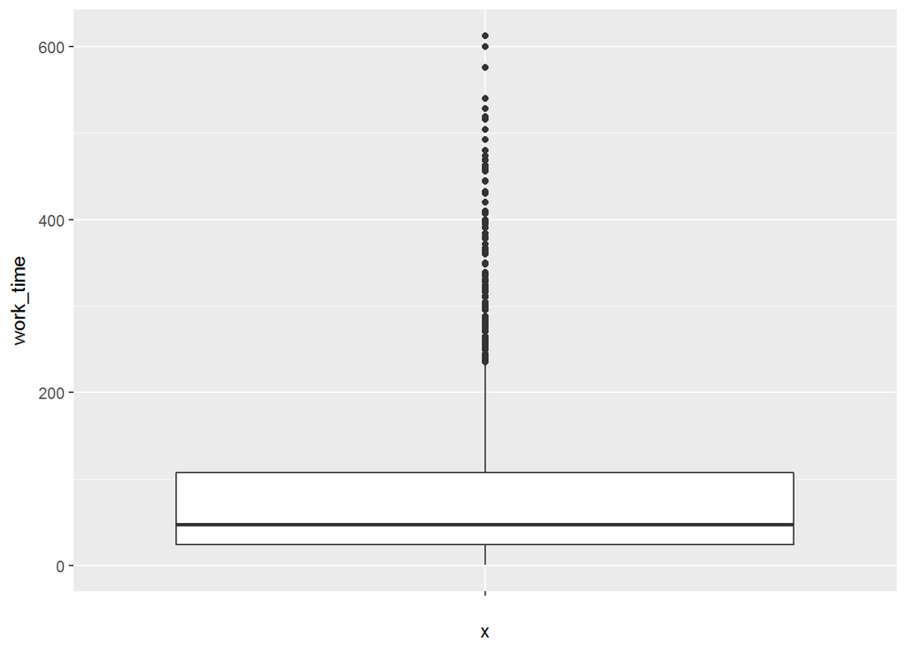

```r
# Напишите свой код в этом блоке
otp <- otp %>%
  mutate(work_time =
           ifelse(work_time > 720 | work_time < 0,
                  NA, work_time))
# Поскольку поле 'work_time' - это время работы на текущем месте в месяцах, то 720 месяцев или 60 лет - это, по нашему мнению, максимальный допустимый стаж работы.
ggplot(otp, aes(x = "", y = work_time)) +
  geom_boxplot()
```

## Работа с пропущенными значениями

В поле с количеством предыдущих кредитных карт - `previous_card_num_utilized` много пропусков, которые обозначают, что у клиента до этого не было кредитных карт, выданных банком. Такие пропущенные значения можно заменить на нули. Для этого можно использовать функцию `if_else()` в сочетании с `is.na()`, но удобнее применить специальную функцию пакета `dplyr` - `coalesce()`.

```r
otp <- otp %>%
  mutate(previous_card_num_utilized =
           coalesce(previous_card_num_utilized, 0))
```

# Портрет клиента

## Возраст

Возраст - это непрерывная (количественная) величина. Для исследования распределения необходимо использовать гистограмму.

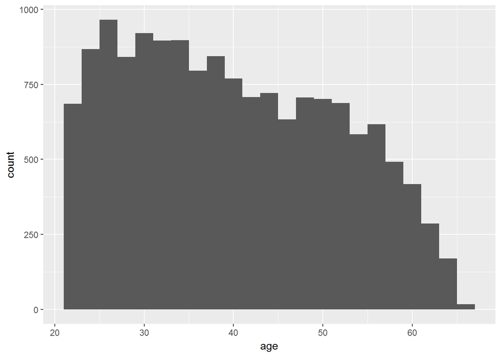

```r
ggplot(otp, aes(x = age)) +
  geom_histogram(binwidth = 2) # Гистограмма
```

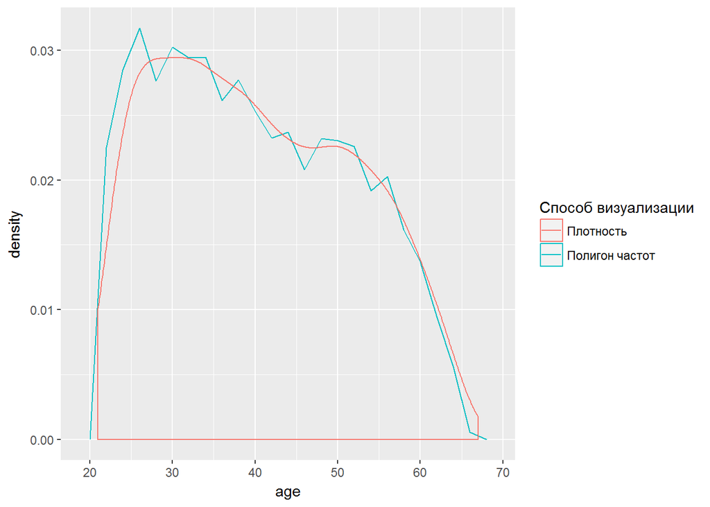

```r
# Альтернативы, удобные для сравнения по подгруппам:
ggplot(otp, aes(x = age)) +
  # Полигон частот
  geom_freqpoly(aes(y = ..density..,
                    color='Полигон частот'),
                binwidth = 2) +
  # Плотность
  geom_density(aes(color='Плотность'), adjust = 1.5)  +

  labs(color = 'Способ визуализации')
```

## Пол

Пол кодируется в данных двумя значениями - 0 и 1.

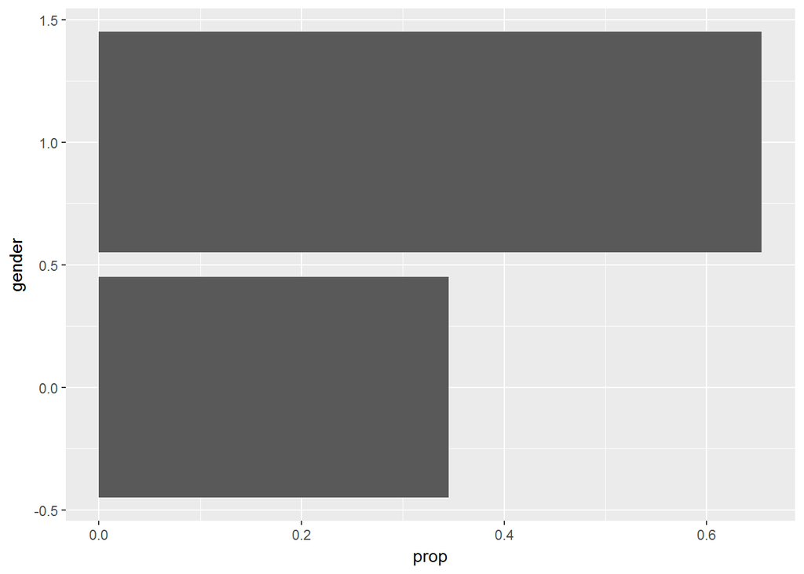

```r
ggplot(otp, aes(x = gender)) +
  geom_bar(aes(y = ..prop.. )) +
  coord_flip()
```

Преобразуем пол в факторную переменную с помощью функции `factor()`. Для факторной переменной можно указать определенный порядок следования уровней и метки для уровней.

```r
otp <- otp %>%
  mutate(genderf = factor(gender,
                          levels = c(0, 1),
                          labels = c('ж','м')))

glimpse(otp$genderf)
```

```
##  Factor w/ 2 levels "ж","м": 2 2 2 2 1 1 1 2 1 2 ...
```

```r
summary(otp$genderf)
```

```
##    ж    м
## 5259 9964
```

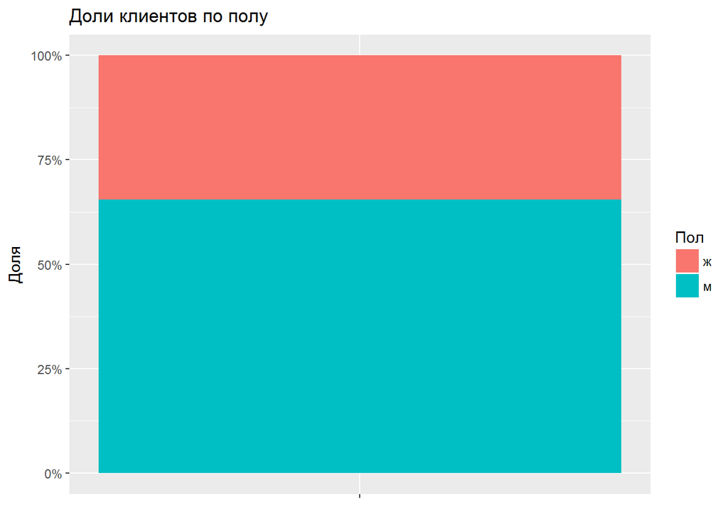

```r
ggplot(otp, aes(x = "")) +
  geom_bar(aes(fill = genderf), position = 'fill')  +
  labs(x = NULL, y = 'Доля',
       title = 'Доли клиентов по полу') +
  labs(fill = 'Пол') +
  scale_y_continuous(labels = percent)
```

Аналогичным образом, создайте факторную переменную `targetf`, которая должна принимать значение `Отклик` (1), если клиент откликнулся на предложение и `Нет отклика` (0), если не откликнулся на предложение.

```r
# Напишите здесь код для добавления переменной targetf в набор otp
otp <- otp %>%
  mutate(targetf = factor(target,
                          levels = c(0, 1),
                          labels = c('нет','да')))

glimpse(otp$targetf)
```

```
##  Factor w/ 2 levels "нет","да": 1 1 1 1 1 1 1 1 1 1 ...
```

```r
summary(otp$targetf)
```

```
##   нет    да
## 13411  1812
```

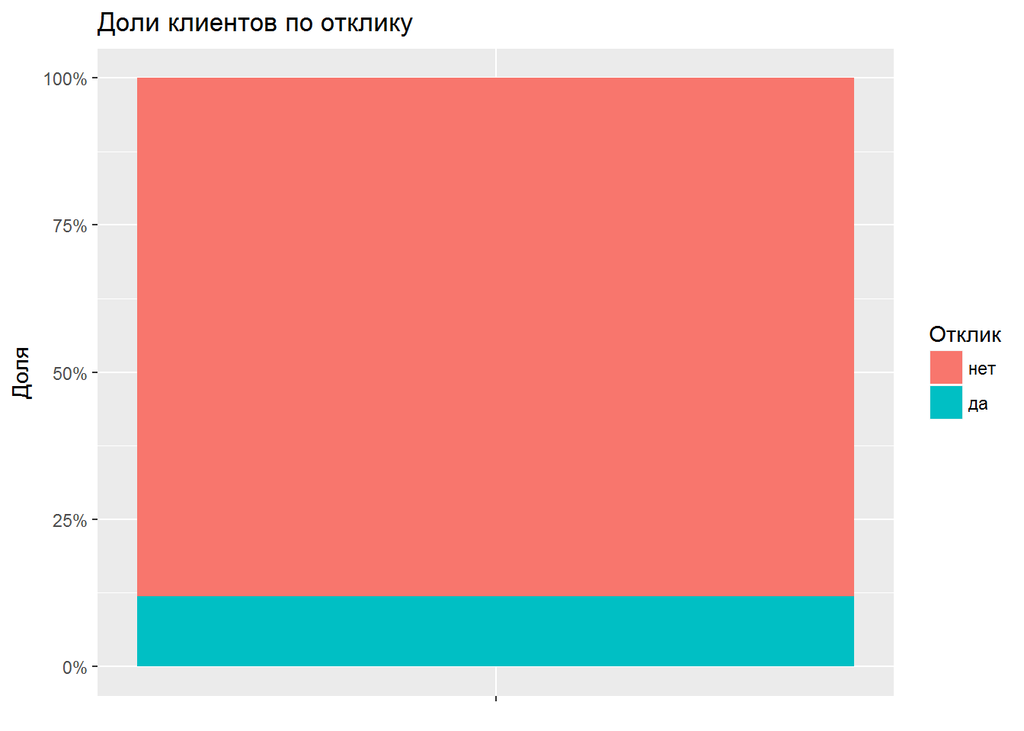

```r
ggplot(otp, aes(x = "")) +
  geom_bar(aes(fill = targetf), position = 'fill')  +
  labs(x = NULL, y = 'Доля',
       title = 'Доли клиентов по отклику') +
  labs(fill = 'Отклик') +
  scale_y_continuous(labels = percent)
```

```r
# Проверьте, сколько значений получилось в каждой категории по отклику и сравните со значениями, указанными во введении

# Переменная targetf включает в себя два значения: "нет" и "да". Значений "нет" - 13411, значений "да" - 1812.
# Значения переменной target из введения:
# 1 — отклик был (1812 клиентов),
# 0 — отклика не было (13411 клиентов).
# Как мы видим, исходные и полученные значения совпадают, то есть замена была проведена верно.
```

## Образование

Уровень образования - дискретная (качественная, или категориальная) переменная. Для анализа ее распределения необходимо использовать столбиковую диаграмму с частотами или относительными частотами.

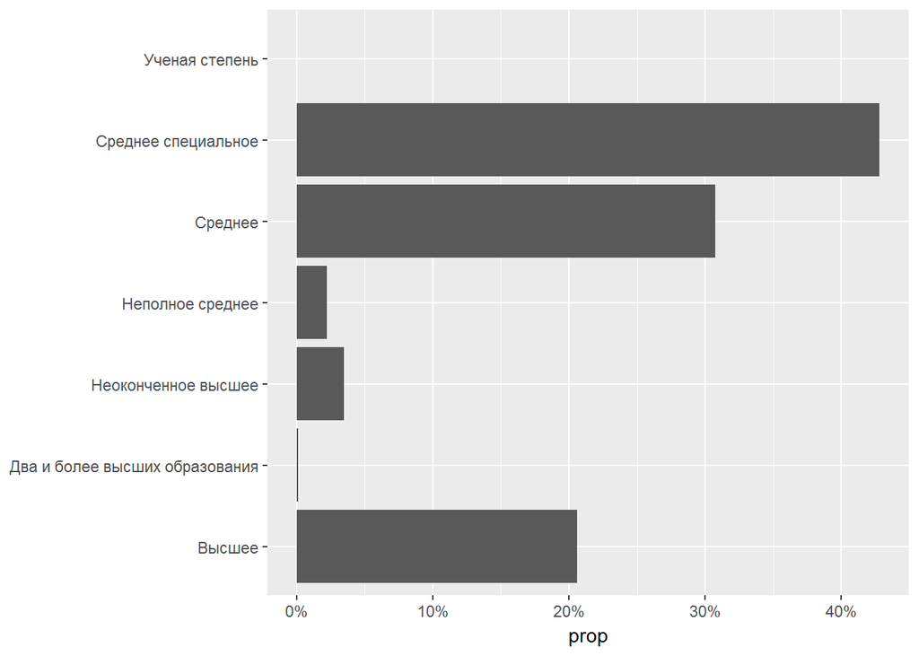

```r
ggplot(otp) +
  geom_bar(aes(x = education, y = ..prop.., group = 1)) +
  scale_y_continuous(labels = percent) +
  labs(x = NULL) +
  coord_flip()
```

Сейчас уровни образования идут в алфавитном порядке. Для облегчения интерпретации результатов необходимо придать категориям какой-либо логический порядок. Уровни этой переменной можно рассматривать как упорядоченные (от самого низкого, до самого высокого уровня). Также можно упорядочить категории по убыванию некоторой их характеристики - например, частоты.

```r
unique(otp$education) # Какие значения есть в данных?
```

```
## [1] "Среднее специальное"            "Среднее"
## [3] "Неполное среднее"               "Высшее"
## [5] "Неоконченное высшее"            "Два и более высших образования"
## [7] "Ученая степень"
```

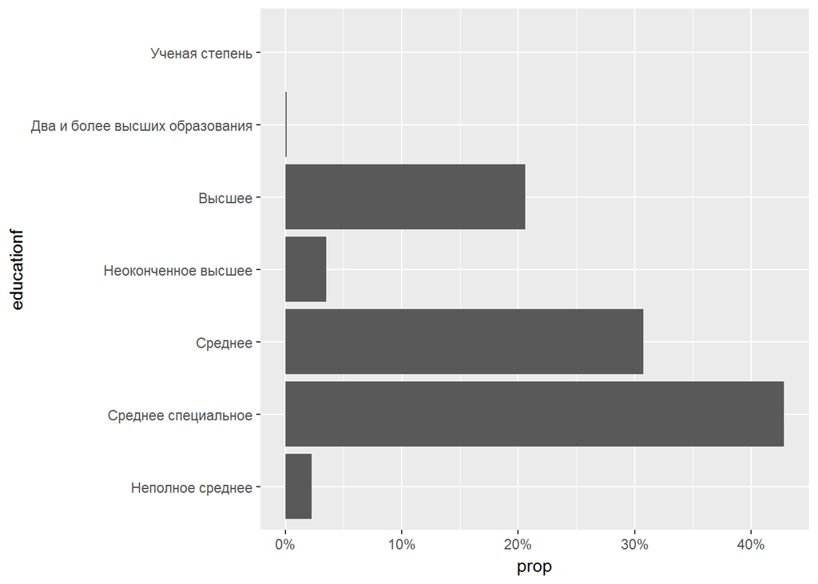

```r
education_levels <-
  c("Неполное среднее",
    "Среднее специальное",
    "Среднее",
    "Неоконченное высшее",
    "Высшее",
    "Два и более высших образования",
    "Ученая степень")



otp <- otp %>%
  mutate(educationf = factor(education, levels = education_levels))

ggplot(otp) +
  geom_bar(aes(x = educationf, y = ..prop.., group = 1)) +
  scale_y_continuous(labels = percent) +
  coord_flip()
```

Теперь категории идут в соответствии с уровнем образования клиента.

Для удобной работы с уровнями факторов был разработан пакет `forcats`. Несколько полезных примеров его использования описаны в [15 главе книги R for Data Science](http://r4ds.had.co.nz/factors.html).

Для переупорядочения уровней фактора по частоте можно использовать функцию `fct_infreq()` Чтобы изменить порядок уровней фактора на обратный, можно использовать функцию `fct_rev()`.

Обе функции можно применять в сочетании с `desc()` для сортировки по убыванию.

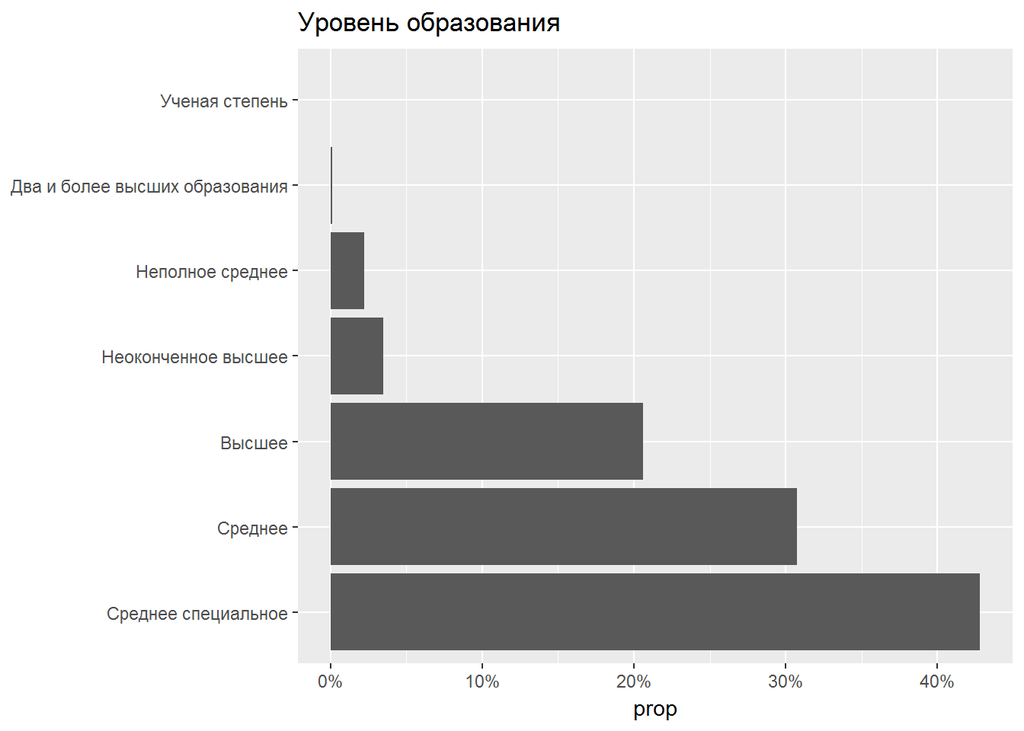

```r
ggplot(otp) + geom_bar(aes(x = fct_infreq(education), y = ..prop.., group = 1)) +
  scale_y_continuous(labels = percent) +
  labs(x = NULL, title = 'Уровень образования') +
  coord_flip()
```

## Профессия

В каких отраслях промышленности работают клиенты банка?

** Совет: ** для упорядочения категорий используйте функцию `fct_infreq()`, фактор заранее создавать не обязательно.

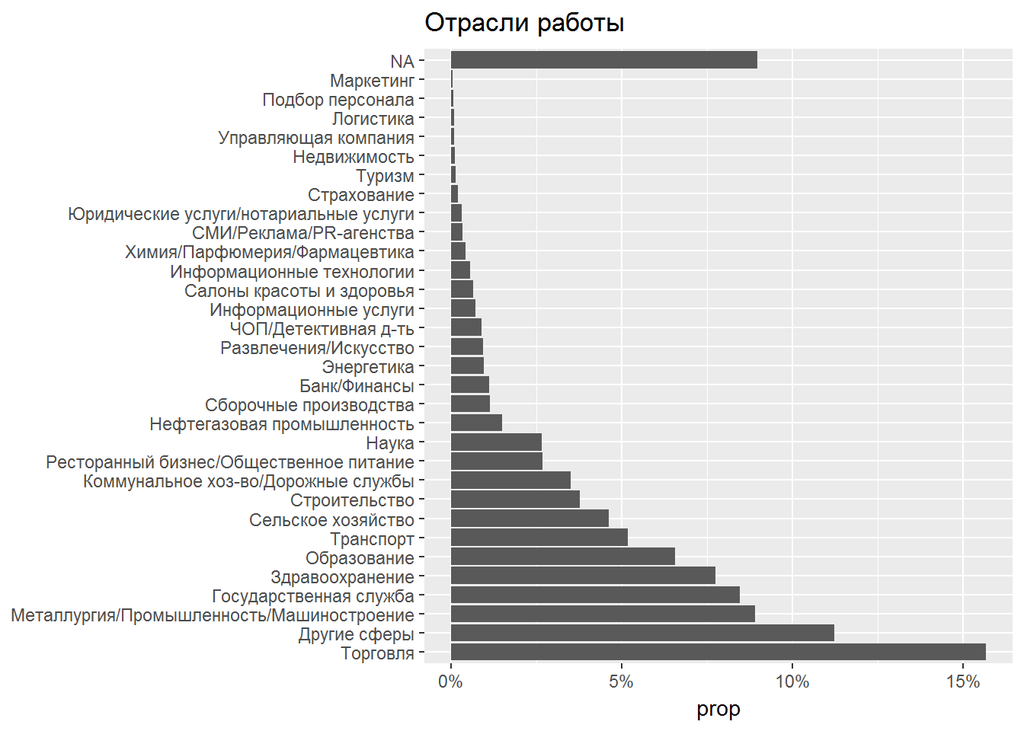

```r
# Напишите здесь свой код
ggplot(otp) +
  geom_bar(aes(x = fct_infreq(gen_industry), y = ..prop.., group = 1)) +
  scale_y_continuous(labels = percent) +
  labs(x = NULL, title = 'Отрасли работы') +
  coord_flip()
```

Как видно из диаграммы, клиенты банка работают в следующих отраслях промышленности: Металлургия/Промышленность/Машиностроение, Нефтегазовая промышленность, Энергетика. Из данных видов промышленности наибольшее число клиентов банка работают в Металлургии/Промышленности/Машиностроении, а наименьшее число работают в Энергетике.

## Сочетание двух факторов

При разведочном анализе интересны сочетания различных переменных, т.к. подобные визуализации могут раскрывать интересные зависимости, которые затем можно использовать при моделировании.

Изучим, как связаны уровень образования и пол. Обе переменные - дискретные, необходимо применить столбиковую диаграмму.

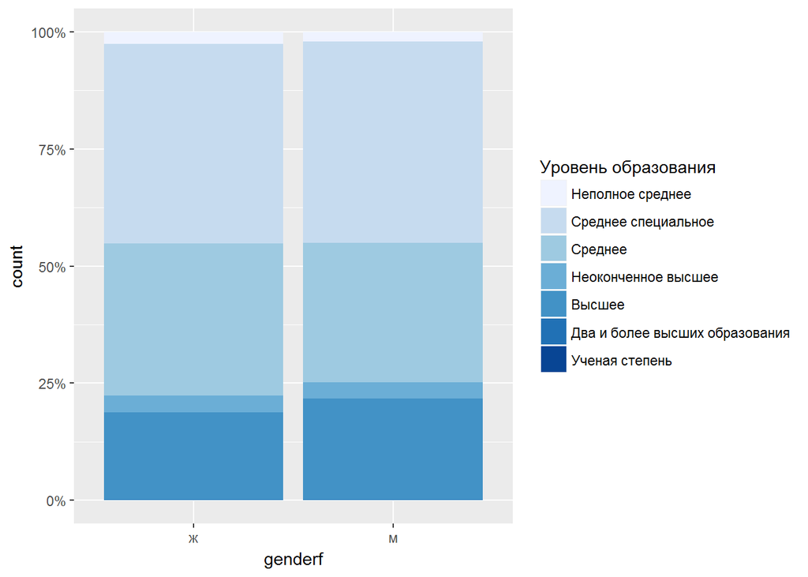

```r
ggplot(otp, aes(x = genderf, fill = educationf)) +
  geom_bar(position = 'fill') +
  scale_fill_brewer(palette = 'Blues') +
  scale_y_continuous(labels = percent) +
  labs(fill = 'Уровень образования')
```

Сравните распределения возраста клиентов в зависимости от пола. Учтите, что возраст - это непрерывная переменная, поэтому для сравнения необходимо использовать гистограмму. А лучше - полигон частот или плотность.

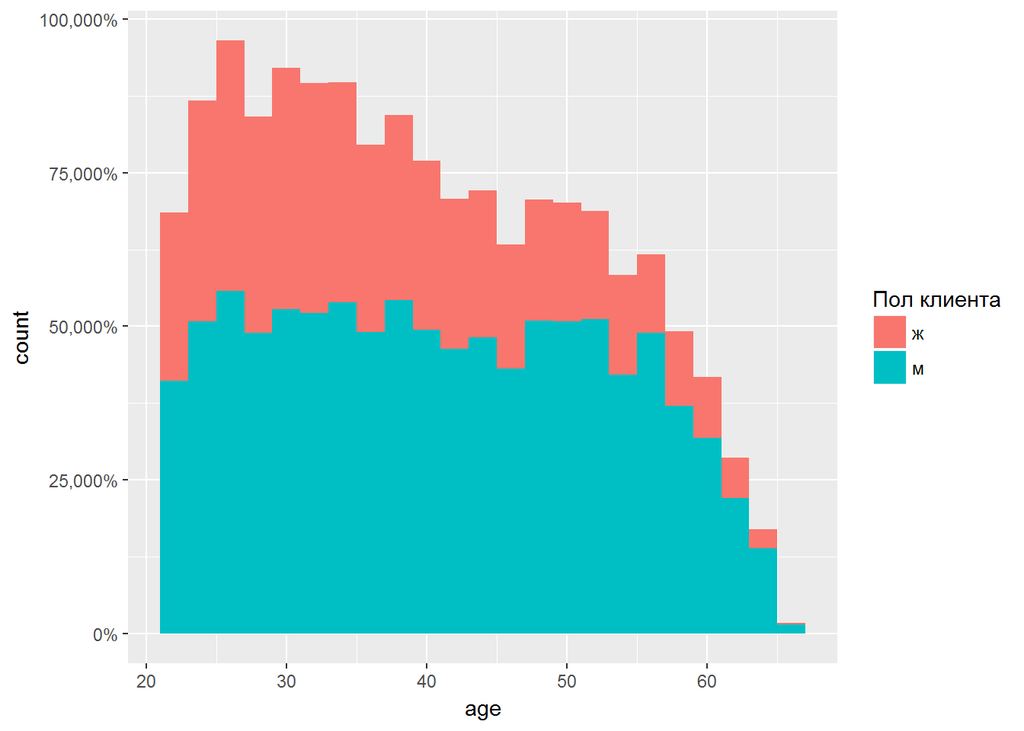

```r
# Гистограмма
ggplot(otp, aes(x = age, fill = genderf)) +
  geom_histogram(binwidth = 2) +
  scale_y_continuous(labels = percent) +
  labs(fill = 'Пол клиента')
```

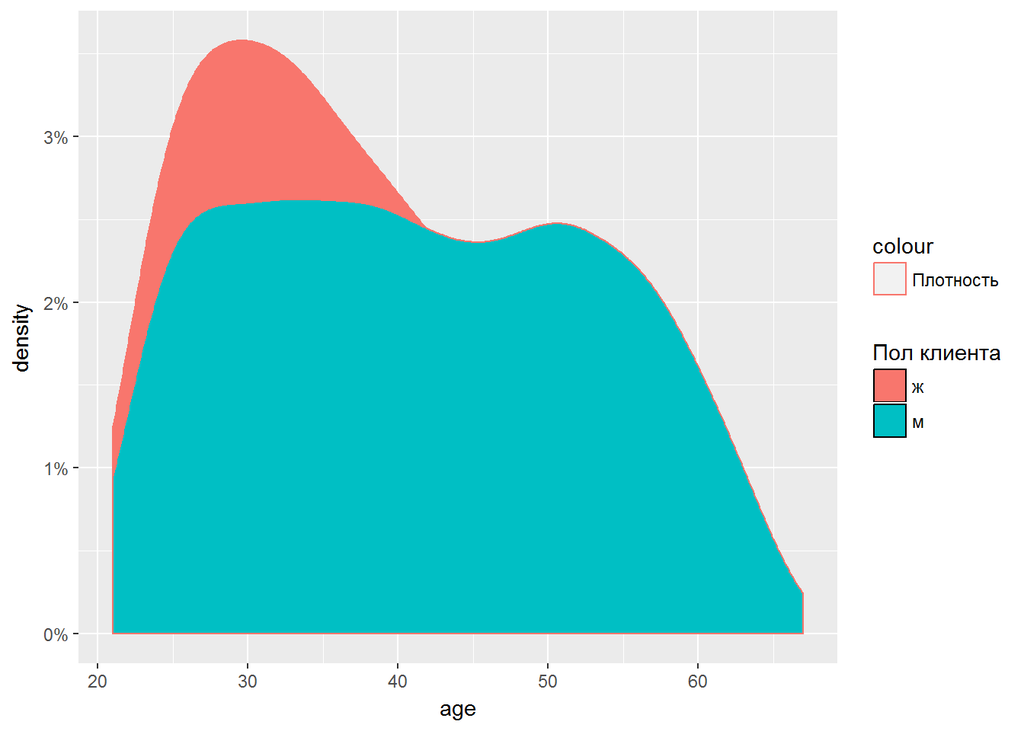

```r
# Плотность
ggplot(otp, aes(x = age, fill = genderf)) +
  geom_density(aes(color='Плотность'), adjust = 1.5)  +
  scale_y_continuous(labels = percent) +
  labs(fill = 'Пол клиента')
```

## Связь дискретной и непрерывной переменной

Если наблюдений мало, то сравнение распределений непрерывной переменной с помощью гистограмм и даже ящичных диаграмм может быть затруднено. В этой ситуации можно сравнивать числовые характеристики распределений для групп.

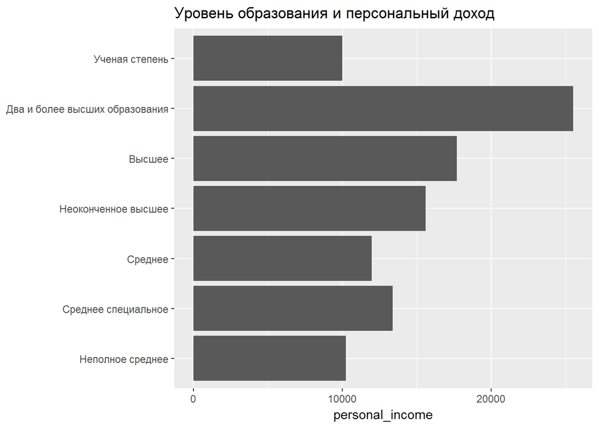

```r
ggplot(otp, aes(x = educationf, y = personal_income)) +
  stat_summary(fun.y = mean, na.rm = T,
               geom = 'bar') +
  labs(x = NULL, title = 'Уровень образования и персональный доход') +
  coord_flip()
```

Упорядочение категорий фактора по среднему личному доходу клиента можно выполнить с помощью функции `fct_reorder(f, x, fun)` (упорядочивает фактор `f` по значению произвольной переменной `x`, к которой применяется агрегирующая функция `fun`).

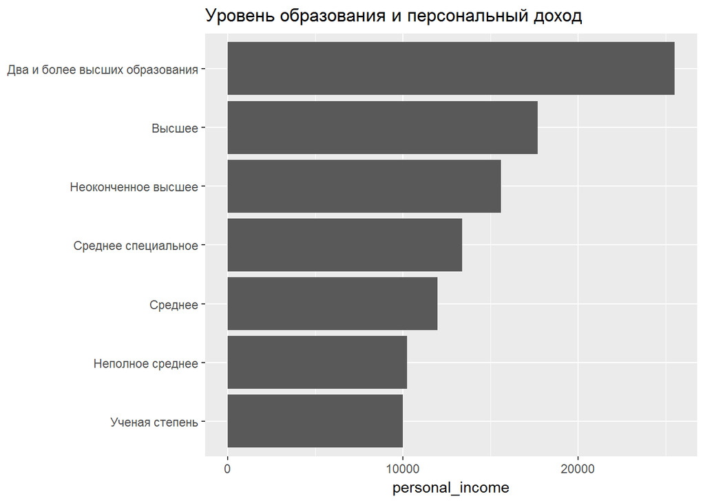

```r
ggplot(otp) +
  stat_summary(aes(x = fct_reorder(education,
                                   personal_income,
                                   fun = mean, na.rm = T),
                   y = personal_income),
               fun.y = mean, na.rm = T,
               geom = 'bar') +
  labs(x = NULL,
       title = 'Уровень образования и персональный доход') +
  coord_flip()
```

Аналогичного результата можно было добиться и рассчитав отдельный набор данных со средними значениями дохода при помощи функций для трансформации данных из пакета `dplyr`.

```r
edu_income <-
  otp %>%
  group_by(educationf) %>%
  summarize(avg_income = mean(personal_income, na.rm = T)) %>%
  arrange(avg_income)

edu_income
```

```
## # A tibble: 7 x 2
##                       educationf avg_income
##                           <fctr>      <dbl>
## 1                 Ученая степень   10000.00
## 2               Неполное среднее   10226.23
## 3                        Среднее   11979.65
## 4            Среднее специальное   13369.49
## 5            Неоконченное высшее   15595.37
## 6                         Высшее   17685.29
## 7 Два и более высших образования   25510.00
```

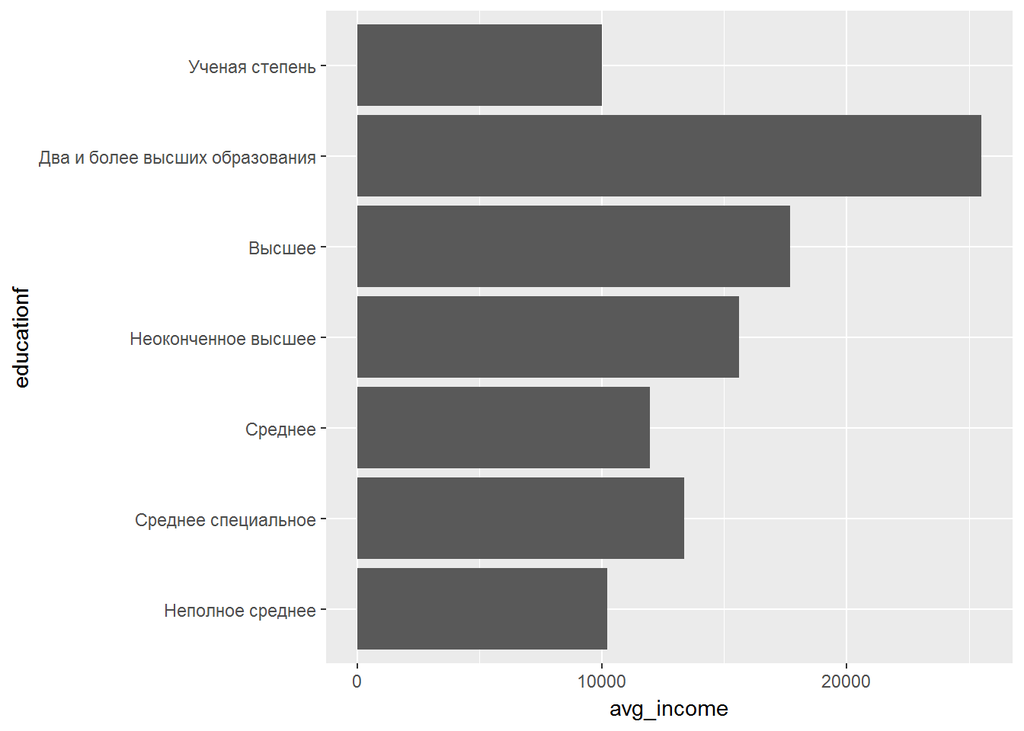

```r
# В порядке увеличения уровня образования
ggplot(edu_income, aes(x = educationf, y = avg_income)) +
  geom_bar(stat = 'identity') + coord_flip()
```

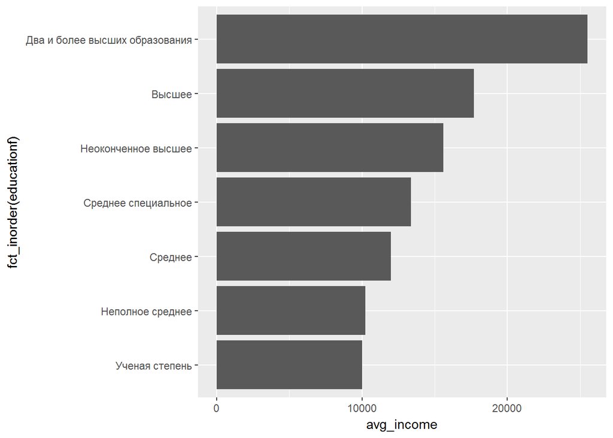

```r
# В порядке увеличения зарплаты
ggplot(edu_income, aes(x = fct_inorder(educationf), y = avg_income)) +
  geom_bar(stat = 'identity') + coord_flip()
```

Изучите, как изменяется доход клиентов в зависимости от профессии

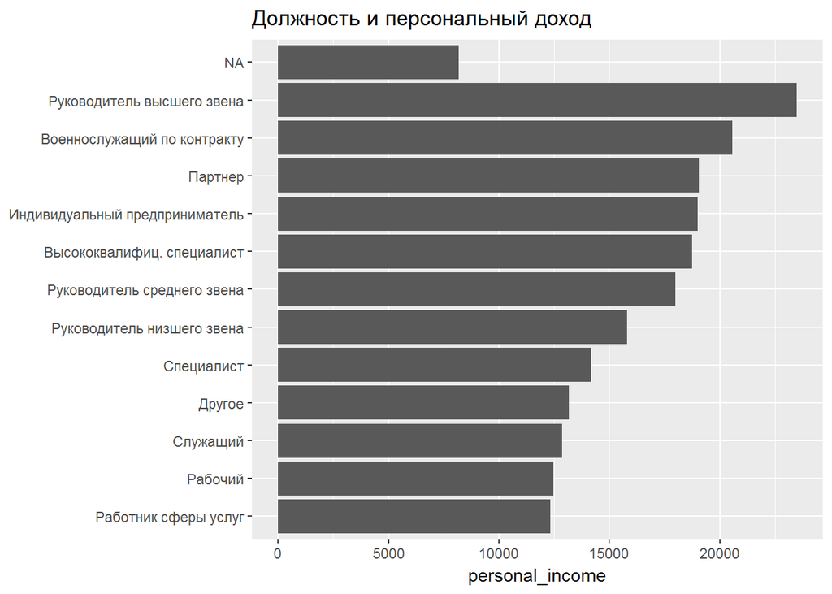

```r
ggplot(otp) +
  stat_summary(aes(x = fct_reorder(gen_title,
                                   personal_income,
                                   fun = mean, na.rm = T),
                   y = personal_income),
               fun.y = mean, na.rm = T,
               geom = 'bar') +
  labs(x = NULL,
       title = 'Должность и персональный доход') +
  coord_flip()
```

Как мы видим, наибольший персональный доход среди клиентов банка у Руководителей высшего звена и Военнослужащих по контракту, а наименьший персональный доход у Рабочих и Работников сферы услуг.

# Исследование влияние различных факторов на целевую переменную

Используя визуализацию, изучите влияние следующих факторов на целевую переменную:

- возраст кол +
- социальный статус (работа, пенсия) кат +
- пол кат +
- количество детей (нет, 1 ребенок, более одного ребенка) кат +
- уровень образования + кат
- семейный статус кат +
- персональный доход + кол
- регион кат +
- наличие автомобиля кат +
- наличие кредита кат +
- наличие просроченных платежей по кредитам кат +
- стаж работы кол

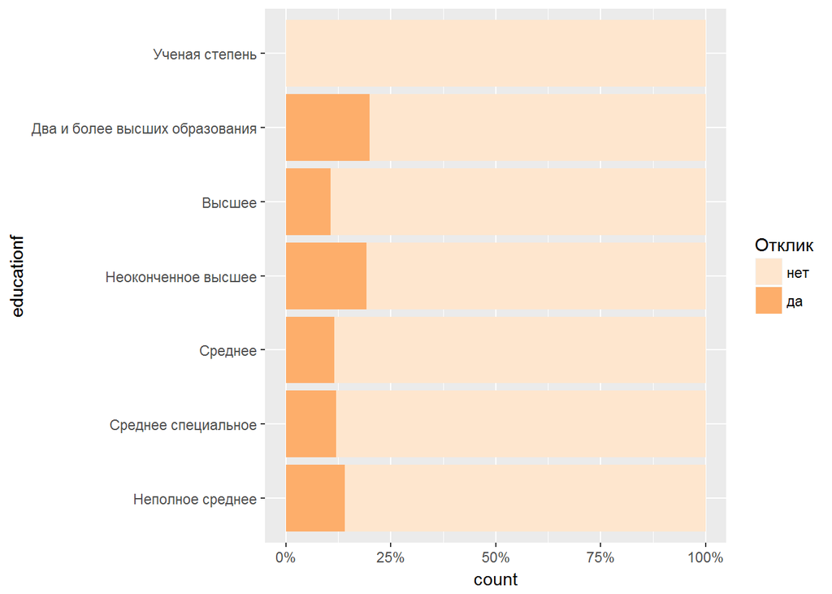

```r
ggplot(otp, aes(x = educationf, fill =  targetf)) +
  geom_bar(position = 'fill') +
  scale_fill_brewer(palette = 'Oranges') +
  scale_y_continuous(labels = percent) +
  labs(fill = 'Отклик') + coord_flip()
```

*** Вывод***: В разрезе процентного соотношения в большей степени в кредите нуждаются люди со Двумя высшими и Неоконченным высшим образованием.

```r
# Уровень образования - дискретная (качественная, или категориальная) переменная, Персональный доход - количественная переменная.
edu_income <-
  otp %>%
  group_by(educationf, targetf) %>%
  summarize(avg_income = mean(personal_income, na.rm = T)) %>%
  arrange(avg_income)

edu_income
```

```
## # A tibble: 13 x 3
## # Groups:   educationf [7]
##                        educationf targetf avg_income
##                            <fctr>  <fctr>      <dbl>
##  1               Неполное среднее     нет   9896.568
##  2                 Ученая степень     нет  10000.000
##  3                        Среднее     нет  11690.683
##  4               Неполное среднее      да  12231.667
##  5            Среднее специальное     нет  13133.285
##  6                        Среднее      да  14208.473
##  7            Среднее специальное      да  15092.036
##  8            Неоконченное высшее     нет  15097.998
##  9                         Высшее     нет  17195.444
## 10            Неоконченное высшее      да  17692.157
## 11                         Высшее      да  21776.570
## 12 Два и более высших образования     нет  23950.000
## 13 Два и более высших образования      да  31750.000
```

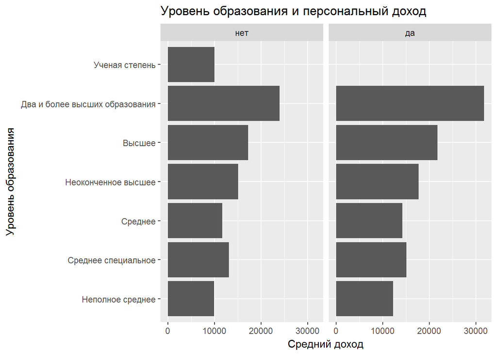

```r
# В порядке увеличения уровня образования
ggplot(edu_income, aes(x = educationf, y = avg_income)) +
  facet_wrap(~targetf, ncol = 2) +
  geom_bar(stat = 'identity') +
labs(x = 'Уровень образования', y = 'Средний доход',
       title = 'Уровень образования и персональный доход', fill="Отклик")  +
coord_flip()
```

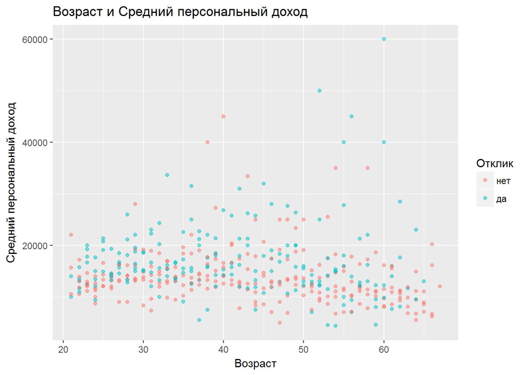

```r
# Возраст - количественная переменная, Персональный доход - количественная переменная.
edu_income <-
  otp %>%
  group_by(educationf, targetf, age) %>%
  summarize(avg_income = mean(personal_income, na.rm = T)) %>%
  arrange(avg_income)


ggplot(edu_income, aes(x=age, y= avg_income)) +
    geom_point(aes (color = targetf), alpha=0.5) +
    ggtitle('Возраст и Средний персональный доход') +
  labs(x = 'Возраст', y = 'Средний персональный доход',
       color ="Отклик")
```

*** Вывод***: Интерес к банку проявили в наибольшей степени люди от 21-22 до 45 лет со средним доходом от 10 до 20 тысяч. Чем старше люди заинтересованные в услугах банка (после 45 лет), тем меньше их доход. Но есть и те категории, у которых доход значительно превышает доход наиболее заинтересованной группы. Для них возможно предложение особых услуг.

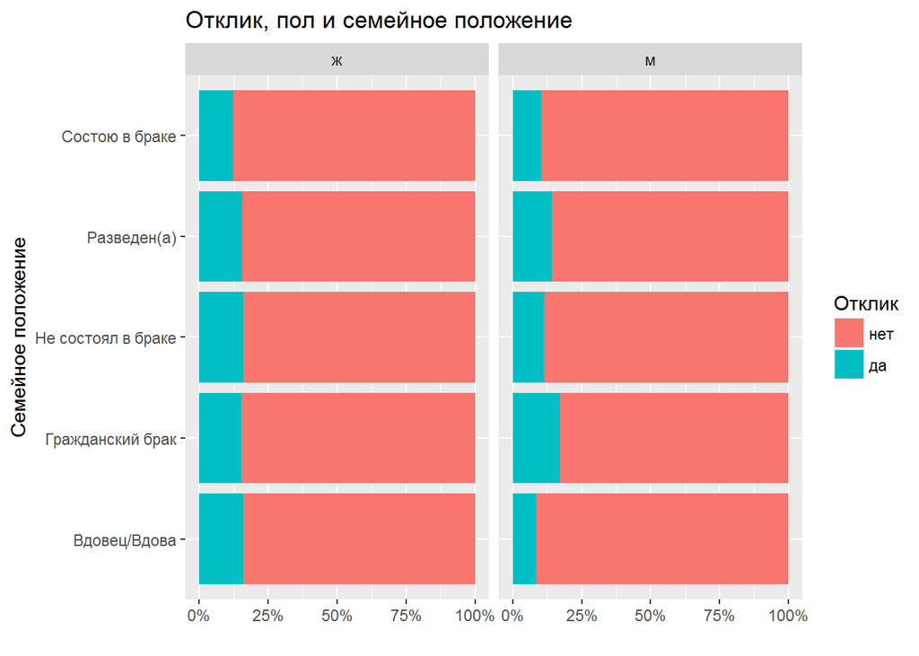

```r
# Пол - категориальная переменная, Семейное положение - категориальная переменная.
ggplot(otp,
  mapping = aes (x = marital_status, fill = targetf , y = ..count..)) +
  geom_bar(position = "fill") +
  facet_wrap(~genderf, ncol = 2) +
  labs(
    title = "Отклик, пол и семейное положение",
    x = "Семейное положение",
    y = "",
    fill ="Отклик") +
  scale_y_continuous(labels = percent) + coord_flip()
```

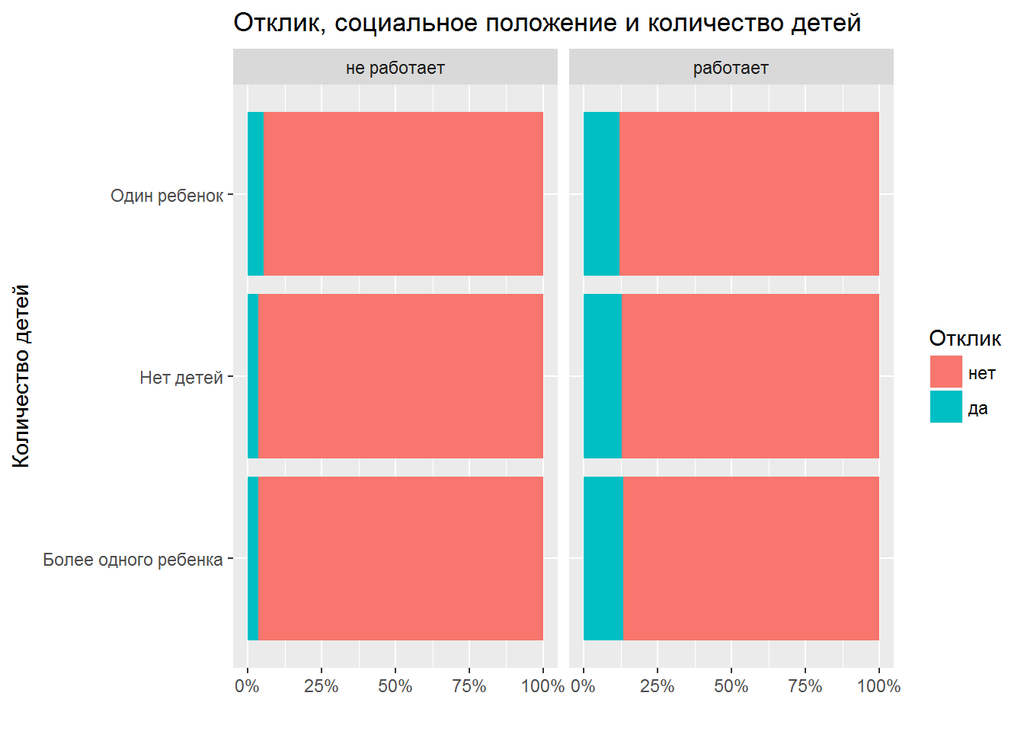

```r
# Количество детей у клиента
otp <- otp %>%
  mutate(child_total_f =
           ifelse(child_total > 1,
                  'Более одного ребенка', ifelse (child_total < 1,
                  'Нет детей', 'Один ребенок')))

ggplot(otp,
  mapping = aes (x = child_total_f, fill = targetf, y = ..count..)) +
  geom_bar(position = "fill") +
  facet_wrap(~socstatus_work_fl, ncol = 2) +
  labs(
    title = "Отклик, социальное положение и количество детей",
    x = "Количество детей",
    y = "",
    fill ="Отклик") +
  scale_y_continuous(labels = percent)  + coord_flip()
```

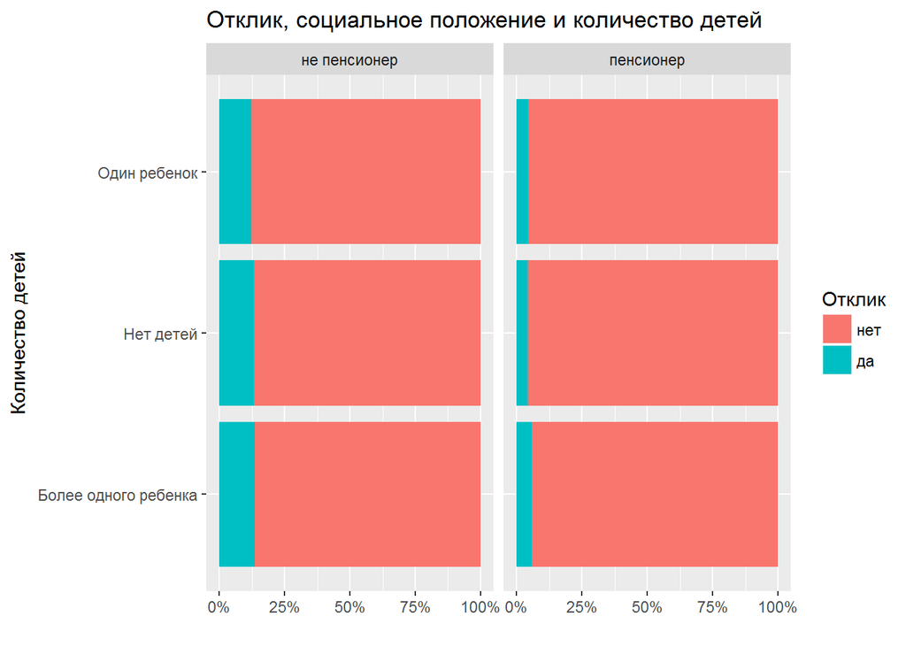

```r
ggplot(otp,
  mapping = aes (x = child_total_f, fill = targetf , y = ..count..)) +
  geom_bar(position = "fill") +
  facet_wrap(~socstatus_pens_fl, ncol = 2) +
  labs(
    title = "Отклик, социальное положение и количество детей",
    x = "Количество детей",
    y = "",
    fill ="Отклик") +
  scale_y_continuous(labels = percent)  + coord_flip()
```

*** Вывод***: В услугах банка руждаются работающие люди (+ не пенсионеры) вне зависимости от наличия детей. Ничтожно малый процент не работающих людей, которые откликнулись на предложение, поэтому фокусироваться на них банку не стоит. Аналогичная ситуация с пенсионерами.

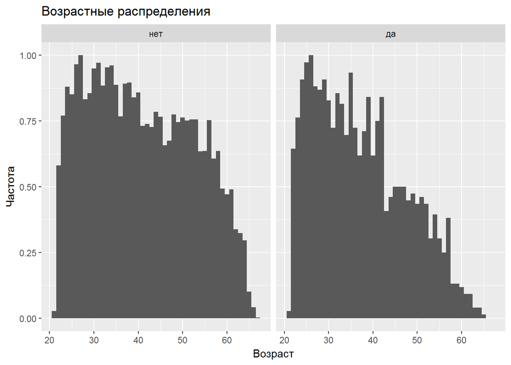

```r
ggplot(data = otp) +
  geom_histogram(mapping = aes(x= age, y = ..ncount..), binwidth =  1) +
  facet_wrap(~targetf) +
  labs(
    title = "Возрастные распределения",
    x = "Возраст",
    y = "Частота"
  )
```

*Вывод*: Откликаются на предложение банка люди в основном люди в возрасте 22-43 года. Именно на них стоит направить основное воздействие. Люди в возрасте 44-55 лет откликаются на подобные предложения гораздо реже.

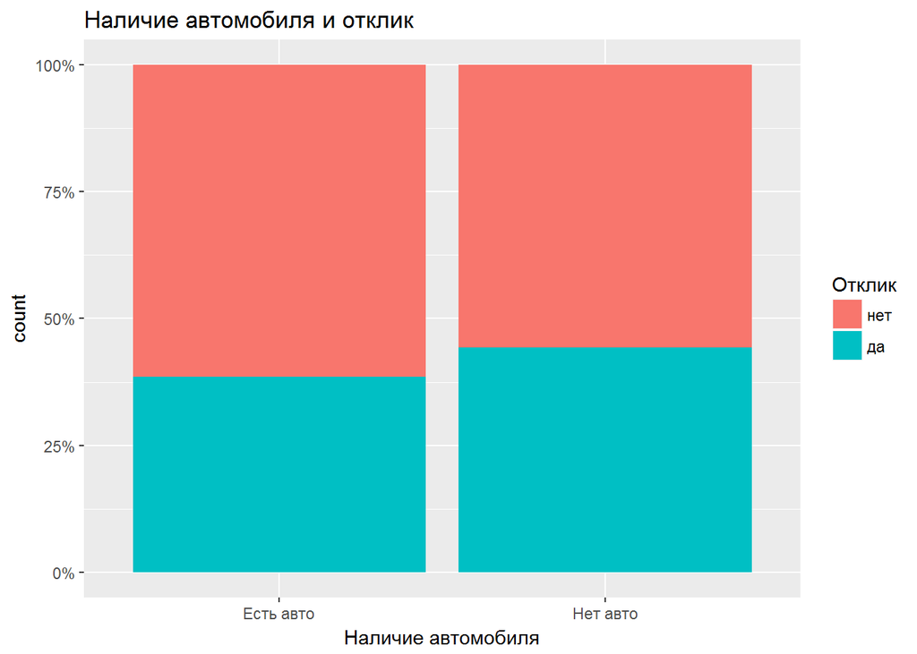

```r
# Наличие автомобиля у клиента
otp <- otp %>%
  mutate(own_auto_f =
           ifelse(own_auto > 0,
                  'Есть авто', 'Нет авто'))
edu_income <-
  otp %>%
  group_by (educationf, targetf, age, own_auto_f ) %>%
  summarize(avg_income = mean(personal_income, na.rm = T)) %>%
  arrange(avg_income)



ggplot(edu_income, aes(x = own_auto_f, y = ..count.., fill = targetf)) +
  geom_bar(position = "fill") +
  scale_y_continuous(labels = percent) +
labs(x = 'Наличие автомобиля',
       title = 'Наличие автомобиля и отклик', fill="Отклик")
```

*** Вывод***: Из тех, кто откликнулся на предложение, больше людей без автомобиля. Возможно, это стоит учитывать банку, поскольку этим клиентам может быть необходим кредит на покупку автомобиля. Однако и те, кто имеет автомобиль, заинтересованы в предложении, но их меньше.

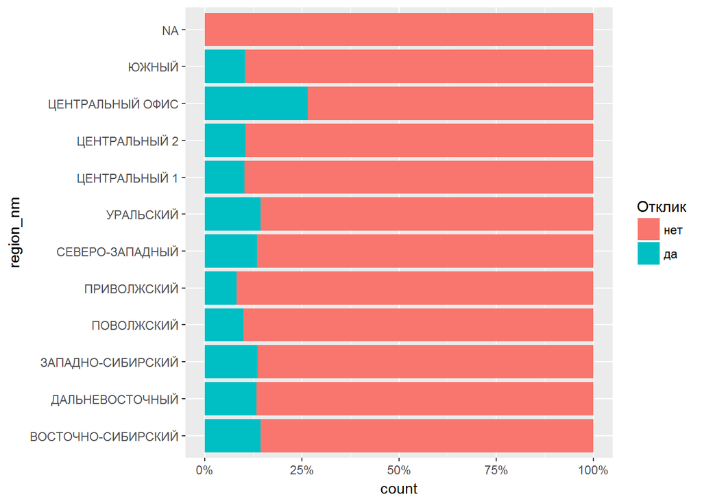

```r
ggplot(otp, aes(x = region_nm, fill = targetf)) +
  geom_bar(position = 'fill') +
  scale_y_continuous(labels = percent) +
  labs(fill = 'Отклик')  + coord_flip()
```

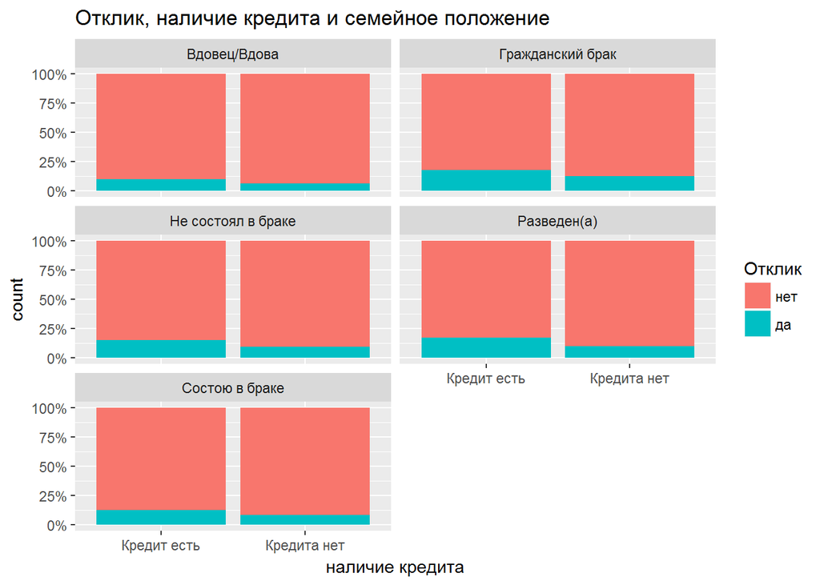

```r
# Наличие кредита у клиента
otp <- otp %>%
  mutate(loan_num =
           ifelse(loan_num_total-loan_num_closed > 0,
                  'Кредит есть', 'Кредита нет'))
ggplot(otp,
  mapping = aes (x = loan_num, fill = targetf, y = ..count..)) +
  geom_bar(position = "fill") +
  facet_wrap(~marital_status, ncol = 2) +
  labs(
    title = "Отклик, наличие кредита и семейное положение",
    x = "наличие кредита",
    fill ="Отклик")+
  scale_y_continuous(labels = percent)
```

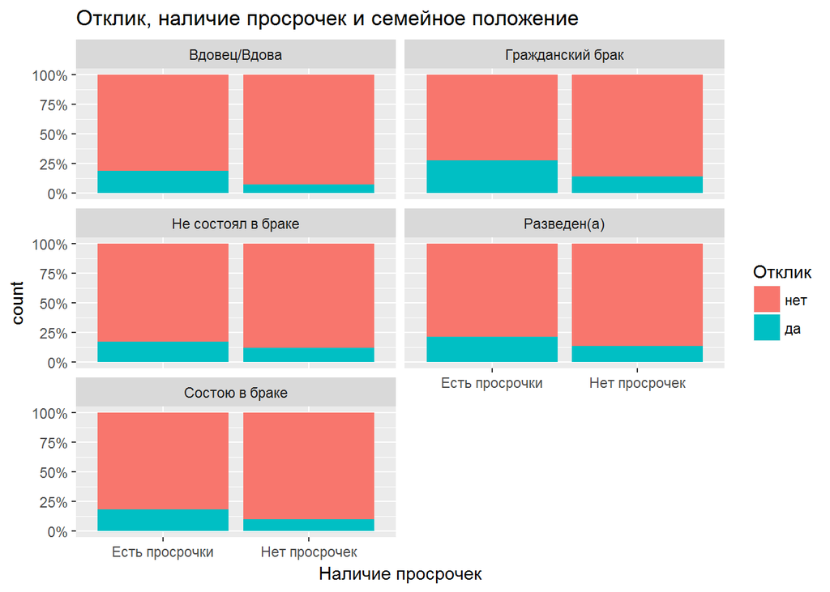

```r
# Наличие просрочек, допущенных клиентом
otp <- otp %>%
  mutate(loan_dlq =
           ifelse(loan_dlq_num > 0,
                  'Есть просрочки', 'Нет просрочек'))
ggplot(otp,
  mapping = aes (x = loan_dlq, fill = targetf, y = ..count..)) +
  geom_bar(position = "fill") +
  facet_wrap(~marital_status, ncol = 2) +
  scale_y_continuous(labels = percent) +
  labs(
    title = "Отклик, наличие просрочек и семейное положение",
    x = "Наличие просрочек",
    fill ="Отклик")
```

*** Вывод***: Вне зависимости от семейного положения, больше на предложение банка откликаются те категории, у которых есть кредит. Аналогичная ситуация с наличием просрочек. Банку стоит помнить, что эти факторы предполагает определенные риски, поэтому необходимо адекватно оценивать финансовые возможности.

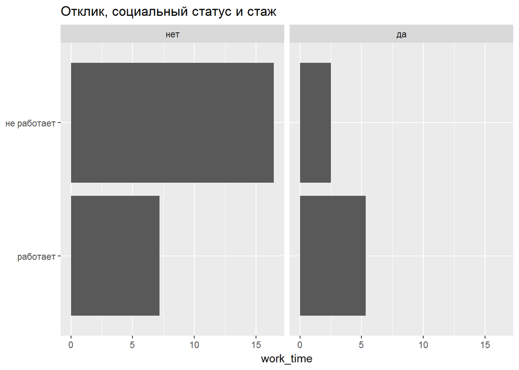

```r
# Стаж работы в годах
otp <- otp %>%
  mutate(work_time = work_time/12)

ggplot(otp) +
  stat_summary(aes(x = fct_reorder(socstatus_work_fl,
                                   work_time,
                                   fun = mean, na.rm = T),
                   y = work_time),
               fun.y = mean, na.rm = T,
               geom = 'bar') +
  facet_wrap(~targetf, ncol = 2) +
  labs(x = NULL,
       title = 'Отклик, социальный статус и стаж', x = "Стаж работы") +
  coord_flip()
```

**Вывод**: Банку стоит сфокусироваться на работающих людей со стажем работы до 5 лет. Однако с осторожностью относиться к тем, у кого почти нет стажа работы, а также к неработающим. Их финансовые возможости необходимо дополнительно проверять.

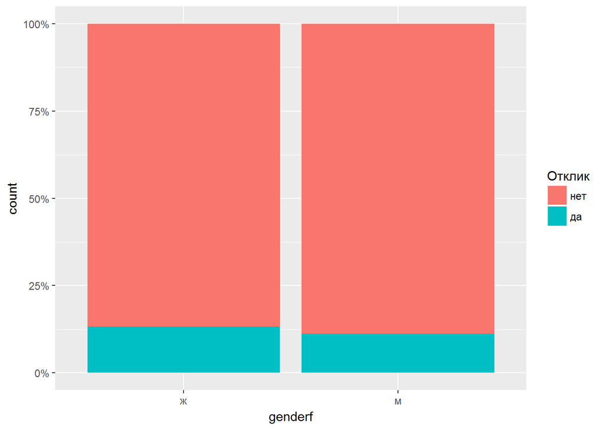

```r
ggplot(otp, aes(x = genderf, fill = targetf)) +
  geom_bar(position = 'fill') +
  scale_y_continuous(labels = percent) +
  labs(fill = 'Отклик')
```

**Вывод**: Мужчины и женщины заинтересованы в предложениях банка в равной степени.